# task_5_motivation

```python
import numpy as np
import pandas as pd
from matplotlib import pyplot as plt
from sklearn.cluster import KMeans
import seaborn as sns
```

```python
servey = pd.read_csv('Motivation.csv')
servey.head()
```

|  | job_market | job_areas | income | requirement | interest | broader_horizon | specializations | further_education | friends | no_idea | family | student_life | academic_title | WU_reputation |
| --- | --- | --- | --- | --- | --- | --- | --- | --- | --- | --- | --- | --- | --- | --- |
| 0 | 1 | 2 | 2 | 4 | 1 | 2 | 1 | 3 | 1 | 1 | 5 | 4 | 2 | 1 |
| 1 | 2 | 3 | 3 | 3 | 1 | 3 | 4 | 5 | 5 | 5 | 4 | 2 | 5 | 3 |
| 2 | 1 | 2 | 1 | 2 | 1 | 1 | 1 | 2 | 4 | 4 | 5 | 4 | 2 | 1 |
| 3 | 2 | 2 | 2 | 2 | 2 | 2 | 4 | 2 | 5 | 2 | 5 | 2 | 2 | 2 |
| 4 | 2 | 2 | 3 | 2 | 3 | 3 | 2 | 4 | 3 | 5 | 1 | 4 | 1 | 2 |

```python
servey.describe()
```

|  | job_market | job_areas | income | requirement | interest | broader_horizon | specializations | further_education | friends | no_idea | family | student_life | academic_title | WU_reputation |
| --- | --- | --- | --- | --- | --- | --- | --- | --- | --- | --- | --- | --- | --- | --- |
| count | 665.000000 | 665.000000 | 665.000000 | 665.000000 | 665.000000 | 665.000000 | 665.000000 | 665.000000 | 665.000000 | 665.000000 | 665.000000 | 665.000000 | 665.000000 | 665.000000 |
| mean | 1.738346 | 1.969925 | 2.463158 | 2.482707 | 1.760902 | 1.948872 | 2.551880 | 3.834586 | 4.415038 | 4.108271 | 4.138346 | 3.470677 | 3.033083 | 2.524812 |
| std | 0.898855 | 0.954853 | 1.180506 | 1.325180 | 0.838623 | 0.988078 | 1.092458 | 1.438396 | 0.959613 | 1.206287 | 1.209446 | 1.240432 | 1.353972 | 1.087886 |
| min | 1.000000 | 1.000000 | 1.000000 | 1.000000 | 1.000000 | 1.000000 | 1.000000 | 1.000000 | 1.000000 | 1.000000 | 1.000000 | 1.000000 | 1.000000 | 1.000000 |
| 25% | 1.000000 | 1.000000 | 2.000000 | 1.000000 | 1.000000 | 1.000000 | 2.000000 | 3.000000 | 4.000000 | 3.000000 | 3.000000 | 3.000000 | 2.000000 | 2.000000 |
| 50% | 2.000000 | 2.000000 | 2.000000 | 2.000000 | 2.000000 | 2.000000 | 2.000000 | 5.000000 | 5.000000 | 5.000000 | 5.000000 | 4.000000 | 3.000000 | 2.000000 |
| 75% | 2.000000 | 2.000000 | 3.000000 | 3.000000 | 2.000000 | 3.000000 | 3.000000 | 5.000000 | 5.000000 | 5.000000 | 5.000000 | 5.000000 | 4.000000 | 3.000000 |
| max | 5.000000 | 5.000000 | 5.000000 | 5.000000 | 5.000000 | 5.000000 | 5.000000 | 5.000000 | 5.000000 | 5.000000 | 5.000000 | 5.000000 | 5.000000 | 5.000000 |

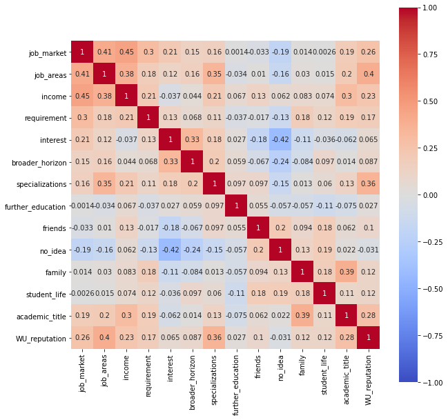

```python
fig, ax = plt.subplots(figsize=(10,10))
map = sns.heatmap(servey.corr(), annot=True, fmt='.2g', cmap="coolwarm", vmin=-1, vmax=1, center= 0, ax=ax, square=True)
```

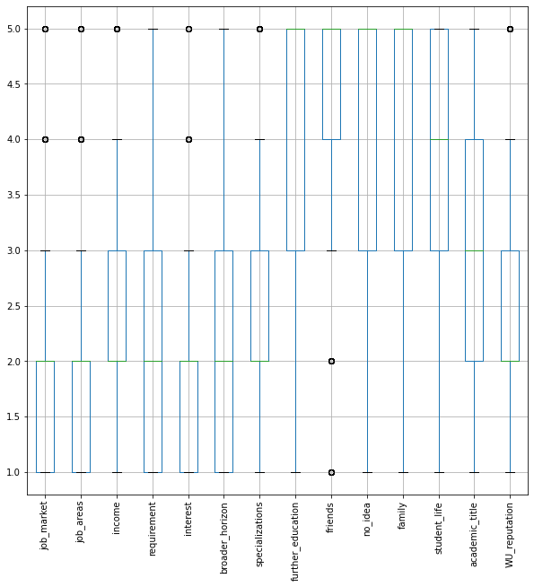

```python
servey.boxplot(figsize=(10,10))
plt.xticks(rotation=90)
plt.show()
```

```python
from pca import pca
servey_pca = pca(n_components=7, normalize=False)
pca_results = servey_pca.fit_transform(servey)
```

```
[pca] >Processing dataframe..
[pca] >The PCA reduction is performed on the [14] columns of the input dataframe.
[pca] >Fitting using PCA..
[pca] >Computing loadings and PCs..
[pca] >Computing explained variance..
[pca] >Outlier detection using Hotelling T2 test with alpha=[0.05] and n_components=[7]
[pca] >Outlier detection using SPE/DmodX with n_std=[2]
```

```python
print(pca_results['PC'].std()**2)
```

```
PC1    3.563895
PC2    2.555316
PC3    2.044818
PC4    1.584535
PC5    1.527567
PC6    1.372201
PC7    1.043965
dtype: float64
```

According to eigenvlues we hve to choose 7 PC, but if we look at the prphic below we will see that after second PC there almost no defference between PC. So for my analysis i will choose 2 PC even tho they explain less than 50%

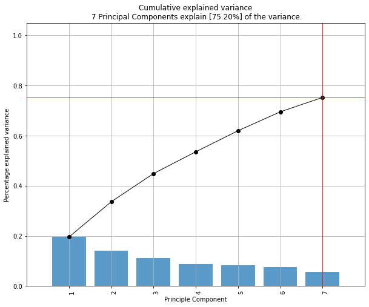

```python
fig, ax = servey_pca.plot()
```

```python
pca_results['loadings']
```

|  | job_market | job_areas | income | requirement | interest | broader_horizon | specializations | further_education | friends | no_idea | family | student_life | academic_title | WU_reputation |
| --- | --- | --- | --- | --- | --- | --- | --- | --- | --- | --- | --- | --- | --- | --- |
| PC1 | 0.252942 | 0.280883 | 0.386289 | 0.395198 | 0.049112 | 0.093356 | 0.255687 | -0.038226 | 0.070678 | -0.057894 | 0.274240 | 0.184386 | 0.493769 | 0.335260 |
| PC2 | 0.167428 | 0.162982 | 0.060970 | 0.087975 | 0.256656 | 0.233394 | 0.234882 | 0.466376 | -0.135430 | -0.492127 | -0.350233 | -0.309181 | -0.235535 | 0.081628 |
| PC3 | 0.082564 | 0.063785 | -0.168263 | 0.227703 | 0.191451 | 0.113846 | -0.051205 | -0.807601 | -0.226398 | -0.351928 | -0.126711 | -0.050940 | -0.084452 | -0.060044 |
| PC4 | 0.034431 | 0.153347 | 0.128231 | -0.171419 | 0.026188 | 0.187776 | 0.291184 | -0.153049 | 0.226418 | 0.219573 | -0.374547 | 0.575959 | -0.417467 | 0.198856 |
| PC5 | 0.069315 | 0.229731 | 0.258169 | -0.636209 | -0.099430 | -0.102144 | 0.146772 | -0.268471 | 0.000984 | 0.080318 | -0.203432 | -0.464613 | 0.248345 | 0.178015 |
| PC6 | -0.223685 | -0.058857 | -0.457205 | -0.449574 | 0.173213 | 0.293667 | 0.245972 | 0.052031 | -0.030354 | -0.316643 | 0.292488 | 0.265449 | 0.284164 | 0.133971 |
| PC7 | 0.191579 | -0.073730 | 0.392940 | -0.247355 | 0.093353 | 0.313560 | -0.420898 | 0.067927 | -0.152289 | -0.133124 | -0.179851 | 0.321159 | 0.278455 | -0.446688 |

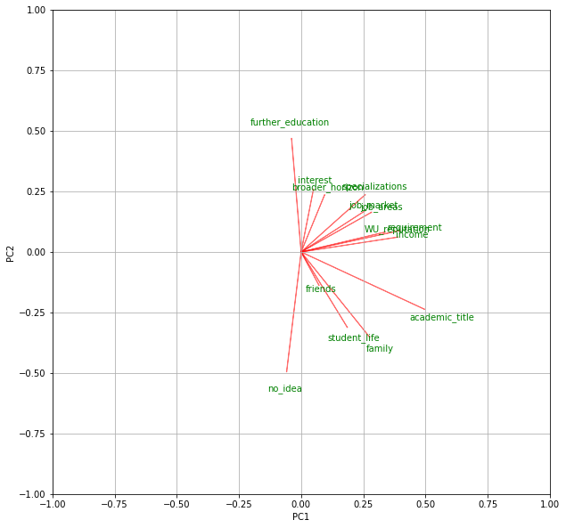

```python
plt.figure(figsize=(10, 10))
coeff = pca_results["loadings"].iloc[0:2,:].transpose()
labels = servey.columns.values
n = coeff.shape[0]
for i in range(n):
   plt.arrow(0, 0, coeff.iloc[i,0], coeff.iloc[i,1],color = 'r',alpha = 0.5)
   plt.text(coeff.iloc[i,0]* 1.15, coeff.iloc[i,1] * 1.15, labels[i], color = 'g', ha = 'center', va = 'center')
plt.xlim(-1,1)
plt.ylim(-1,1)
plt.xlabel("PC{}".format(1))
plt.ylabel("PC{}".format(2))
plt.grid()
plt.show()
```

We can see mainly two groups: -for one group of students the most important reasons were: further_education, specialiations, requirement, interest, broader_horizon, job_market, job_areas, income, WU_reputation

-for the second one it is: friends, no_idea, student_life, family, academic_titile

So what can we say? That for some students it was sort of random choice defined by things that are not connected to future job, or they just wanted to get a degree because it is important for them or their family And for some students it was a conscious choice based on their interest in business or future job.

```python
sse = []
k_rng = range(1,10)
for k in k_rng:
    km = KMeans(n_clusters=k)
    km.fit(servey)
    sse.append(km.inertia_)
```

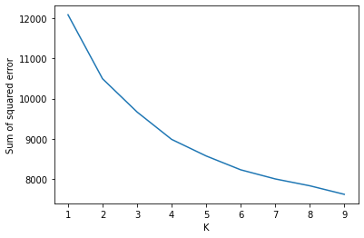

```python
plt.xlabel('K')
plt.ylabel('Sum of squared error')
plt.plot(k_rng,sse)
```

We graph the relationship between the number of clusters and Within Cluster Sum of Squares (WCSS) then we select the number of clusters where the change in WCSS begins to level off (elbow method). For as it is k = 4

```python
km = KMeans(n_clusters=2, n_init=75).fit(servey)
```

```python
servey['cluster']=km.labels_
servey = servey.reset_index()
servey = servey.rename({'index': 'number'}, axis='columns')
#just changing DataFrame a littlebit
```

```python
pc = servey_pca.results['PC'].iloc[:, 0:2]
pc
```

|  | PC1 | PC2 |
| --- | --- | --- |
| 0 | -0.903914 | 0.695014 |
| 1 | 1.964921 | 0.784233 |
| 2 | -2.097375 | -2.124347 |
| 3 | -0.395662 | 0.847561 |
| 4 | -1.991725 | 1.674156 |
| ... | ... | ... |
| 660 | 2.613084 | -1.661178 |
| 661 | -0.217120 | 2.575652 |
| 662 | -1.189566 | 1.350962 |
| 663 | 1.121284 | 1.400492 |
| 664 | 0.693160 | -0.835917 |

665 rows × 2 columns

```python
proj_cluster_means = servey_pca.transform(np.array(km.cluster_centers_))
```

```
[pca] >Column labels are auto-completed.
[pca] >Row labels are auto-completed.
```

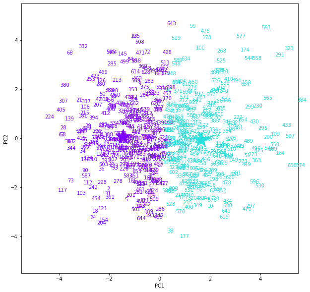

```python
fig = plt.figure(figsize=(10, 10))
ax = plt.axis([-5.5, 5.5, -5.5, 5.5])
colors = plt.cm.get_cmap("rainbow", 4)
for index, row in pc.iterrows():
    color = colors(km.labels_[index])
    plt.text(row["PC1"], row["PC2"], servey["number"][index], {"color": color})
for index in range(0, proj_cluster_means["PC1"].values.shape[0]):
    m1 = proj_cluster_means["PC1"].values[index]
    m2 = proj_cluster_means["PC2"].values[index]
    plt.plot(m1, m2, color=colors(index), marker="*", markersize=32)

plt.xlabel("PC1")
plt.ylabel("PC2")
plt.show()
```

```python
df = pd.DataFrame({'centers0': km.cluster_centers_[0], 'centers1': km.cluster_centers_[1], 'names': km.feature_names_in_})
df
```

|  | centers0 | centers1 | names |
| --- | --- | --- | --- |
| 0 | 1.423295 | 2.092652 | job_market |
| 1 | 1.559659 | 2.431310 | job_areas |
| 2 | 1.903409 | 3.092652 | income |
| 3 | 1.980114 | 3.047923 | requirement |
| 4 | 1.732955 | 1.792332 | interest |
| 5 | 1.826705 | 2.086262 | broader_horizon |
| 6 | 2.178977 | 2.971246 | specializations |
| 7 | 3.892045 | 3.769968 | further_education |
| 8 | 4.295455 | 4.549521 | friends |
| 9 | 4.187500 | 4.019169 | no_idea |
| 10 | 3.727273 | 4.600639 | family |
| 11 | 3.198864 | 3.776358 | student_life |
| 12 | 2.244318 | 3.920128 | academic_title |
| 13 | 2.019886 | 3.092652 | WU_reputation |

```python
from kmeans_interp.kmeans_feature_imp import KMeansInterp
```

```python
servey_f = servey.drop('cluster', axis='columns')
servey_f = servey_f.drop('number', axis='columns')
```

```python
kmf = KMeansInterp(
	n_clusters=2,
	ordered_feature_names=servey_f.columns.tolist(),
	feature_importance_method='wcss_min',
).fit(servey_f.values)
```

```python
kmf.feature_importances_[0]
```

```
[('friends', 4.295454545454546),
 ('no_idea', 4.1875),
 ('further_education', 3.892045454545455),
 ('family', 3.727272727272728),
 ('student_life', 3.198863636363636),
 ('academic_title', 2.2443181818181803),
 ('specializations', 2.178977272727274),
 ('WU_reputation', 2.0198863636363638),
 ('requirement', 1.9801136363636362),
 ('income', 1.9034090909090913),
 ('broader_horizon', 1.8267045454545447),
 ('interest', 1.7329545454545454),
 ('job_areas', 1.5596590909090922),
 ('job_market', 1.4232954545454553)]
```

```python
kmf.feature_importances_[1]
```

```
[('family', 4.600638977635783),
 ('friends', 4.5495207667731625),
 ('no_idea', 4.019169329073482),
 ('academic_title', 3.920127795527155),
 ('student_life', 3.776357827476038),
 ('further_education', 3.7699680511182114),
 ('WU_reputation', 3.092651757188498),
 ('income', 3.092651757188498),
 ('requirement', 3.0479233226837064),
 ('specializations', 2.9712460063897774),
 ('job_areas', 2.4313099041533555),
 ('job_market', 2.092651757188499),
 ('broader_horizon', 2.086261980830671),
 ('interest', 1.792332268370607)]
```

firstly, I did 4 clusters and three of them was similar, so I decided to reduce it to two